# Choropleth Visualization of U.S. Mortality from Diseases of the Heart

#### AltantiCare Data Scientist Internship

#### 8 January 2018

## Introduction:

Heart disease is the leading cause of death in the United States. According to the Center of Disease Control (CDC), heart disease is attributed to more than 600,000 annual deaths. Additionally, heart disease is the leading cause of death for both men *and* women, although men are statistically at a greater risk for developing heart disease than women [[1](https://www.cdc.gov/heartdisease/facts.htm)].

The term 'heart disease' refers to several aliments/conditions of the heart; the most common condition is conorary artery disease (atherosclerosis), which is a precursor to a heart attack. Other notable conditions that are defined as heart disease include ischemic and hemorraghic stroke, heart failure, arrhythmia, and heart valve complications such as stenois and prolapse. In order to provide adqeuate healthcare to treat heart disease across the United States, data visualization techniques such as choropleth mapping can be implemented to show comparative heart disease trends categorized by state and gender.

The CDC's Divison of Population Health provides yearly statistics of over 124 chronic health disease indicators that are reported on a city and state level. Using Python's leading data manipulation library, Pandas, and Plotly's choropleth maps API, this dataset will be filtered and manipulated to display data for only mortality from diseases of the heart for the year 2014 and by gender. This CSV file, last updated on December 5th, 2017, will be used for this study [[2](https://chronicdata.cdc.gov/api/views/g4ie-h725/rows.csv?accessType=DOWNLOAD&api_foundry=true)].

## Importing & Manipulating the Dataset:

Before importing the CSV file, the directory must be changed to the location of the CSV file:

```python
cd ~/Desktop
```

```
/Users/johnsokol/Desktop
```

Importing the CSV file directly from the CDC can be completed using the following pandas command:

```python
import pandas as pd
cdc_url = 'https://chronicdata.cdc.gov/api/views/g4ie-h725/rows.csv?accessType=DOWNLOAD&api_foundry=true'
us_diseases_ind = pd.read_csv(cdc_url, low_memory=False)
```

Let's acquire information regarding the attributes of the dataset by observing the first 3 rows, the size of the dataset, and the datatypes that are populated in each column:

```python
us_diseases_ind.head(3)
```

|  | YearStart | YearEnd | LocationAbbr | LocationDesc | DataSource | Topic | Question | Response | DataValueUnit | DataValueType | ... | LocationID | TopicID | QuestionID | DataValueTypeID | StratificationCategoryID1 | StratificationID1 | StratificationCategoryID2 | StratificationID2 | StratificationCategoryID3 | StratificationID3 |
| --- | --- | --- | --- | --- | --- | --- | --- | --- | --- | --- | --- | --- | --- | --- | --- | --- | --- | --- | --- | --- | --- |
| 0 | 2015 | 2015 | AK | Alaska | YRBSS | Alcohol | Alcohol use among youth | NaN | % | Crude Prevalence | ... | 2 | ALC | ALC1_1 | CrdPrev | OVERALL | OVR | NaN | NaN | NaN | NaN |
| 1 | 2015 | 2015 | AL | Alabama | YRBSS | Alcohol | Alcohol use among youth | NaN | % | Crude Prevalence | ... | 1 | ALC | ALC1_1 | CrdPrev | OVERALL | OVR | NaN | NaN | NaN | NaN |
| 2 | 2015 | 2015 | AR | Arkansas | YRBSS | Alcohol | Alcohol use among youth | NaN | % | Crude Prevalence | ... | 5 | ALC | ALC1_1 | CrdPrev | OVERALL | OVR | NaN | NaN | NaN | NaN |

3 rows × 34 columns

```python
us_diseases_ind.shape
```

```
(406480, 34)
```

There are 406,480 rows and 34 columns of data.

```python
us_diseases_ind.info()
```

```
<class 'pandas.core.frame.DataFrame'>
RangeIndex: 406480 entries, 0 to 406479
Data columns (total 34 columns):
YearStart                    406480 non-null int64
YearEnd                      406480 non-null int64
LocationAbbr                 406480 non-null object
LocationDesc                 406480 non-null object
DataSource                   406480 non-null object
Topic                        406480 non-null object
Question                     406480 non-null object
Response                     79323 non-null object
DataValueUnit                375783 non-null object
DataValueType                406480 non-null object
DataValue                    300289 non-null object
DataValueAlt                 276138 non-null float64
DataValueFootnoteSymbol      188067 non-null object
DatavalueFootnote            187901 non-null object
LowConfidenceLimit           248467 non-null float64
HighConfidenceLimit          248467 non-null float64
StratificationCategory1      406480 non-null object
Stratification1              406480 non-null object
StratificationCategory2      79323 non-null object
Stratification2              79323 non-null object
StratificationCategory3      79323 non-null object
Stratification3              79323 non-null object
GeoLocation                  403864 non-null object
ResponseID                   79323 non-null object
LocationID                   406480 non-null int64
TopicID                      406480 non-null object
QuestionID                   406480 non-null object
DataValueTypeID              406480 non-null object
StratificationCategoryID1    406480 non-null object
StratificationID1            406480 non-null object
StratificationCategoryID2    79324 non-null object
StratificationID2            79324 non-null object
StratificationCategoryID3    79323 non-null object
StratificationID3            79323 non-null object
dtypes: float64(3), int64(3), object(28)
memory usage: 105.4+ MB
```

The .info( ) method is notably significant, in particular because it conveys the memory usage of the dataset. This dataset uses approximately 105.4 MB of memory. Due to this high memory value, this may cause performance issues upon further manipulation and analysis. Therefore, we can change all the columns of type 'object' to type 'category' to reduce memory usage using the following command:

```python
us_diseases_cat = pd.concat([us_diseases_ind.select_dtypes([], ['object']),
us_diseases_ind.select_dtypes(['object']).apply(pd.Series.astype, dtype='category')],
axis=1).reindex_axis(us_diseases_ind.columns, axis=1)
```

Now let's observe the memory usage of the modified dataset:

```python
us_diseases_cat.info()
```

```
<class 'pandas.core.frame.DataFrame'>
RangeIndex: 406480 entries, 0 to 406479
Data columns (total 34 columns):
YearStart                    406480 non-null int64
YearEnd                      406480 non-null int64
LocationAbbr                 406480 non-null category
LocationDesc                 406480 non-null category
DataSource                   406480 non-null category
Topic                        406480 non-null category
Question                     406480 non-null category
Response                     79323 non-null category
DataValueUnit                375783 non-null category
DataValueType                406480 non-null category
DataValue                    300289 non-null category
DataValueAlt                 276138 non-null float64
DataValueFootnoteSymbol      188067 non-null category
DatavalueFootnote            187901 non-null category
LowConfidenceLimit           248467 non-null float64
HighConfidenceLimit          248467 non-null float64
StratificationCategory1      406480 non-null category
Stratification1              406480 non-null category
StratificationCategory2      79323 non-null category
Stratification2              79323 non-null category
StratificationCategory3      79323 non-null category
Stratification3              79323 non-null category
GeoLocation                  403864 non-null category
ResponseID                   79323 non-null category
LocationID                   406480 non-null int64
TopicID                      406480 non-null category
QuestionID                   406480 non-null category
DataValueTypeID              406480 non-null category
StratificationCategoryID1    406480 non-null category
StratificationID1            406480 non-null category
StratificationCategoryID2    79324 non-null category
StratificationID2            79324 non-null category
StratificationCategoryID3    79323 non-null category
StratificationID3            79323 non-null category
dtypes: category(28), float64(3), int64(3)
memory usage: 31.4 MB
```

The memory usage decreased 74 MB. This should assuage future performance concerns.

This dataset provides a great amount of infomation. However, this study only demands a few columns for data analysis of heart disease mortality. Important columns include YearStart, YearEnd, Question, DataValueUnit, DataValueType, DataValue, and Stratification1 (gender). So columns that are not needed can be dropped from the dataset.

```python
us_diseases_drop = us_diseases_cat.drop(['DataValueFootnoteSymbol', 'DatavalueFootnote','GeoLocation',
'ResponseID','LocationID','TopicID','QuestionID','DataValueTypeID','StratificationCategoryID2',
'StratificationID2','StratificationCategoryID3','StratificationID3','StratificationCategoryID1',
'StratificationID1','StratificationCategory1','StratificationCategory2','StratificationCategory3'], axis = 1)
```

```python
us_diseases_drop.head(3)
```

|  | YearStart | YearEnd | LocationAbbr | LocationDesc | DataSource | Topic | Question | Response | DataValueUnit | DataValueType | DataValue | DataValueAlt | LowConfidenceLimit | HighConfidenceLimit | Stratification1 | Stratification2 | Stratification3 |
| --- | --- | --- | --- | --- | --- | --- | --- | --- | --- | --- | --- | --- | --- | --- | --- | --- | --- |
| 0 | 2015 | 2015 | AK | Alaska | YRBSS | Alcohol | Alcohol use among youth | NaN | % | Crude Prevalence | 22 | 22.0 | 19.7 | 24.5 | Overall | NaN | NaN |
| 1 | 2015 | 2015 | AL | Alabama | YRBSS | Alcohol | Alcohol use among youth | NaN | % | Crude Prevalence | 30.7 | 30.7 | 27.3 | 34.3 | Overall | NaN | NaN |
| 2 | 2015 | 2015 | AR | Arkansas | YRBSS | Alcohol | Alcohol use among youth | NaN | % | Crude Prevalence | 27.6 | 27.6 | 24.5 | 30.8 | Overall | NaN | NaN |

```python
print(us_diseases_drop.shape)
```

```
(406480, 17)
```

Half of the columns were determined to be unnecessary for this study and were dropped from the dataset that will be analyzed. The next step is to find the data that is related to heart disease. This can be completed by observing all unqiue values in the 'Question' column:

```python
from pandas.api.types import CategoricalDtype
questions = us_diseases_drop.iloc[:,6].unique()

for i in questions:
    print(i)
```

```
Alcohol use among youth
Binge drinking prevalence among youth
Binge drinking prevalence among adults aged >= 18 years
Asthma mortality rate
Binge drinking prevalence among women aged 18-44 years
Binge drinking intensity among adults aged >= 18 years who binge drink
Binge drinking frequency among adults aged >= 18 years who binge drink
Heavy drinking among adults aged >= 18 years
Arthritis among adults aged >= 18 years
Heavy drinking among women aged 18-44 years
Arthritis among adults aged >= 18 years who are obese
Asthma prevalence among women aged 18-44 years
Current asthma prevalence among adults aged >= 18 years
Arthritis among adults aged >= 18 years who have diabetes
Mammography use among women aged 50-74 years
Arthritis among adults aged >= 18 years who have heart disease
Activity limitation due to arthritis among adults aged >= 18 years
Papanicolaou smear use among adult women aged 21-65 years
Recent Papanicolaou smear use among women aged 21-44 years
Diabetes prevalence among women aged 18-44 years
Physical inactivity among adults aged >= 18 years with arthritis
Gini Index of income inequality
Fair or poor health among adults aged >= 18 years with arthritis
Adults aged >= 18 years with arthritis who have taken a class to learn how to manage arthritis symptoms
Influenza vaccination among noninstitutionalized adults aged 18-64 years with asthma
Influenza vaccination among noninstitutionalized adults aged >= 65 years with asthma
Pneumococcal vaccination among noninstitutionalized adults aged 18-64 years with asthma
Pneumococcal vaccination among noninstitutionalized adults aged >= 65 years with asthma
Current smoking among adults aged >= 18 years
Fecal occult blood test, sigmoidoscopy, or colonoscopy among adults aged 50-75 years
Current cigarette smoking among youth
Prevalence of chronic kidney disease among adults aged >= 18 years
Prevalence of chronic obstructive pulmonary disease among adults >= 18
Cholesterol screening among adults aged >= 18 years
Current cigarette smoking among women aged 18-44 years
Prevalence of chronic obstructive pulmonary disease among adults >= 45 years
Prevalence of current smoking among adults >= 18 with diagnosed chronic obstructive pulmonary disease
Prevalence of current smoking among adults >= 45 years with diagnosed chronic obstructive pulmonary disease
Prevalence of activity limitation among adults >= 18 with diagnosed chronic obstructive pulmonary disease
Current smokeless tobacco use among adults aged >= 18 years
```

[output cut: 149 more lines]

```
Hospitalization for chronic obstructive pulmonary disease as any diagnosis among Medicare-eligible persons aged >= 65 years
Prevalence of gestational diabetes
Hospitalization for heart failure among Medicare-eligible persons aged >= 65 years
Hospitalization for hip fracture among Medicare-eligible persons aged >= 65 years
Prevalence of pre-pregnancy diabetes
Postpartum depressive symptoms
Preventive dental care before pregnancy
Health insurance coverage before pregnancy
Postpartum checkup
Presence of regulations pertaining to screen time in early care and education settings
Presence of regulations pertaining to avoiding sugar in early care and education settings
Life expectancy at birth
Life expectancy at age 65 years
Cancer of the colon and rectum (colorectal), incidence
Cancer of the colon and rectum (colorectal), mortality
```

Towards the bottom of this list is the question 'Mortality from diseases of the heart'. This is the question that will be filtered for the study.

```python
us_diseases_drop_arg = us_diseases_drop['Question'] == 'Mortality from diseases of the heart'
us_diseases_heart = us_diseases_drop[us_diseases_drop_arg]
us_diseases_heart.head(3)
```

|  | YearStart | YearEnd | LocationAbbr | LocationDesc | DataSource | Topic | Question | Response | DataValueUnit | DataValueType | DataValue | DataValueAlt | LowConfidenceLimit | HighConfidenceLimit | Stratification1 | Stratification2 | Stratification3 |
| --- | --- | --- | --- | --- | --- | --- | --- | --- | --- | --- | --- | --- | --- | --- | --- | --- | --- |
| 223555 | 2014 | 2014 | NE | Nebraska | NVSS | Cardiovascular Disease | Mortality from diseases of the heart |  | NaN | Number | 3296 | 3296.0 | NaN | NaN | Overall |  |  |
| 223799 | 2014 | 2014 | NM | New Mexico | NVSS | Cardiovascular Disease | Mortality from diseases of the heart |  | NaN | Number | 3424 | 3424.0 | NaN | NaN | Overall |  |  |
| 223893 | 2014 | 2014 | SD | South Dakota | NVSS | Cardiovascular Disease | Mortality from diseases of the heart |  | NaN | Number | 1704 | 1704.0 | NaN | NaN | Overall |  |  |

The data must now be further filtered by gender, Data Value Type of 'Adge-Adjusted Rate', and for the year 2014.

Female mortality from diseases of the heart:

```python
us_diseases_heart_female_arg = us_diseases_heart['Stratification1'] == 'Female'
us_diseases_heart_female = us_diseases_heart[us_diseases_heart_female_arg]

us_dis_heart_female_age_arg = us_diseases_heart_female['DataValueType'] == 'Age-adjusted Rate'
us_dis_heart_female_age = us_diseases_heart_female[us_dis_heart_female_age_arg]

us_dis_heart_female_year_arg = us_dis_heart_female_age['YearStart'] == 2014
us_dis_heart_female_final = us_dis_heart_female_age[us_dis_heart_female_year_arg]
us_dis_heart_female_final.head(3)
```

|  | YearStart | YearEnd | LocationAbbr | LocationDesc | DataSource | Topic | Question | Response | DataValueUnit | DataValueType | DataValue | DataValueAlt | LowConfidenceLimit | HighConfidenceLimit | Stratification1 | Stratification2 | Stratification3 |
| --- | --- | --- | --- | --- | --- | --- | --- | --- | --- | --- | --- | --- | --- | --- | --- | --- | --- |
| 239423 | 2014 | 2014 | AK | Alaska | NVSS | Cardiovascular Disease | Mortality from diseases of the heart |  | cases per 100,000 | Age-adjusted Rate | 109 | 109.0 | 96.0 | 121.9 | Female |  |  |
| 239431 | 2014 | 2014 | AL | Alabama | NVSS | Cardiovascular Disease | Mortality from diseases of the heart |  | cases per 100,000 | Age-adjusted Rate | 182.5 | 182.5 | 177.8 | 187.2 | Female |  |  |
| 239439 | 2014 | 2014 | AR | Arkansas | NVSS | Cardiovascular Disease | Mortality from diseases of the heart |  | cases per 100,000 | Age-adjusted Rate | 169.8 | 169.8 | 164.0 | 175.6 | Female |  |  |

```python
us_dis_heart_female_final.shape
```

```
(51, 17)
```

The filtering commands successfully narrowed down the dataset to the appropriate information needed for visualization and analysis, confirmed by observing the dataset with the head method and the 51 rows, one row for each state and the District of Columbia.

Male mortality from diseases of the heart:

```python
us_diseases_heart_male_arg = us_diseases_heart['Stratification1'] == 'Male'
us_diseases_heart_male = us_diseases_heart[us_diseases_heart_male_arg]

us_dis_heart_male_age_arg = us_diseases_heart_male['DataValueType'] == 'Age-adjusted Rate'
us_dis_heart_male_age = us_diseases_heart_male[us_dis_heart_male_age_arg]

us_dis_heart_male_year_arg = us_dis_heart_male_age['YearStart'] == 2014
us_dis_heart_male_final = us_dis_heart_male_age[us_dis_heart_male_year_arg]
us_dis_heart_male_final.head(3)
```

|  | YearStart | YearEnd | LocationAbbr | LocationDesc | DataSource | Topic | Question | Response | DataValueUnit | DataValueType | DataValue | DataValueAlt | LowConfidenceLimit | HighConfidenceLimit | Stratification1 | Stratification2 | Stratification3 |
| --- | --- | --- | --- | --- | --- | --- | --- | --- | --- | --- | --- | --- | --- | --- | --- | --- | --- |
| 239425 | 2014 | 2014 | AK | Alaska | NVSS | Cardiovascular Disease | Mortality from diseases of the heart |  | cases per 100,000 | Age-adjusted Rate | 188.3 | 188.3 | 169.5 | 207.1 | Male |  |  |
| 239433 | 2014 | 2014 | AL | Alabama | NVSS | Cardiovascular Disease | Mortality from diseases of the heart |  | cases per 100,000 | Age-adjusted Rate | 277.5 | 277.5 | 270.5 | 284.5 | Male |  |  |
| 239441 | 2014 | 2014 | AR | Arkansas | NVSS | Cardiovascular Disease | Mortality from diseases of the heart |  | cases per 100,000 | Age-adjusted Rate | 274 | 274.0 | 265.4 | 282.5 | Male |  |  |

The filtered dataset for males is also verified for correct observations.

```python
us_dis_heart_male_final.shape
```

```
(51, 17)
```

## Exploratory Data Analysis (EDA):

Now that both male and female datasets were manipulated, we can use plotly's chorpleth map API to visualize the data superimposed on a map of the United States.

```python
import plotly.plotly as py
import plotly.graph_objs as go
from plotly import tools
from plotly.offline import iplot, init_notebook_mode
init_notebook_mode()

scl = [[0.0, 'rgb(242,240,247)'],[0.2, 'rgb(218,218,235)'],[0.4, 'rgb(188,189,220)'],[0.6, 'rgb(158,154,200)'],[0.8,'rgb(117,107,177)'],[1.0, 'rgb(84,39,14)']]

# # male mortality from diseases of the heart
data = [dict(
        type = 'choropleth',
        colorscale = scl,
        autocolorscale = False,
        locations = us_dis_heart_male_final['LocationAbbr'],
        z = us_dis_heart_male_final['DataValue'],
        zmin = 80,
        zmax = 300,
        locationmode = 'USA-states',
        marker = dict(
            line = dict (
                color = 'rgb(255, 255, 255)',
                width = 1.5,
            )),
        colorbar = dict(
            title = 'Cases per 100,000 People',
            ticks = 'outside',
            dtick = 30,
            )
        )]

layout = dict(
        title = 'Male Mortality from Diseases of the Heart (2014)',
        geo = dict(
            scope = 'usa',
            projection = dict( type='albers usa'),
            showlakes = True,
            lakecolor = 'rgb(255, 255, 255)',
            countrycolor = 'rgb(255, 255, 255)')
            )

figure = dict(data= data, layout = layout)

iplot(figure)
```

[interactive chart not shown]

Similarly, the same code can be applied for the female demographic:

```python
# female mortality from diseases of the heart
data = [dict(
        type = 'choropleth',
        colorscale = scl,
        autocolorscale = False,
        locations = us_dis_heart_female_final['LocationAbbr'],
        z = us_dis_heart_female_final['DataValue'],
        zmin = 80,
        zmax = 300,
        locationmode = 'USA-states',
        marker = dict(
            line = dict (
                color = 'rgb(255, 255, 255)',
                width = 1.5,
            )),
        colorbar = dict(
            title = 'Cases per 100,000 People',
            ticks = 'outside',
            dtick = 30,
            )
        )]

layout = dict(
        title = 'Female Mortality from Diseases of the Heart (2014)',
        geo = dict(
            scope = 'usa',
            projection = dict( type='albers usa' ),
            showlakes = True,
            lakecolor = 'rgb(255, 255, 255)',
            countrycolor = 'rgb(255, 255, 255)')
            )

figure = dict(data=data, layout=layout)

iplot(figure)
```

[interactive chart not shown]

## Visualization Analysis:

According to these choropleth visualizations, it is clear that the male demographic experiences more cases of mortality due to heart disease than females. However, these maps do not convey the distribution of the data, which will be investigated using traditional histograms and ECDF's (Empirical Cumulative Distribution Function).

Histograms based on gender (bins = 7):

```python
data_values_male = us_dis_heart_male_final['DataValue'].values
data_values_male = pd.to_numeric(data_values_male, errors = 'coerce')

data_values_female = us_dis_heart_female_final['DataValue'].values
data_values_female = pd.to_numeric(data_values_female, errors = 'coerce')
```

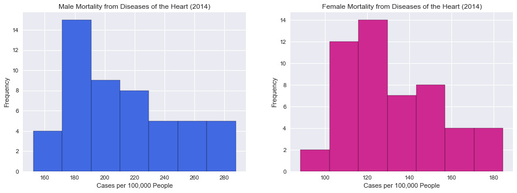

```python
import numpy as np

plt.rcParams["patch.force_edgecolor"] = True

fig, ax = plt.subplots(1,2,figsize=(15,5))
ax[0].hist(data_values_male, bins = (int(np.sqrt(len(data_values_male)))), color = '#4169E1')
ax[0].title.set_text('Male Mortality from Diseases of the Heart (2014)')
ax[0].set_xlabel('Cases per 100,000 People')
ax[0].set_ylabel('Frequency')

ax[1].hist(data_values_female, bins = int(np.sqrt(len(data_values_female))),color = '#CD2990')
ax[1].title.set_text('Female Mortality from Diseases of the Heart (2014)')
ax[1].set_xlabel('Cases per 100,000 People')
ax[1].set_ylabel('Frequency')
plt.show()
```

Empirical Cumulative Distribution Functions (ECDF):

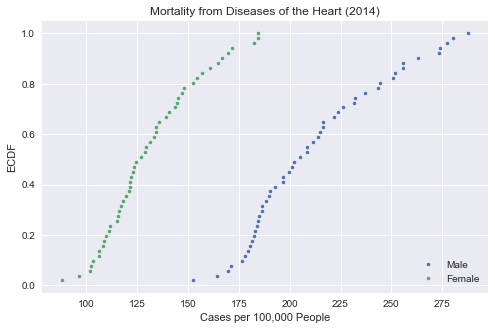

```python
def ecdf(data):
    """Compute ECDF for a one-dimensional array of measurements."""

    # Number of data points: n
    n = len(data)

    # x-data for the ECDF: x
    x = np.sort(data)

    # y-data for the ECDF: y
    y = np.arange(1, n+1) / n

    return x, y

fig, ax = plt.subplots(figsize=(8,5))
x_male, y_male = ecdf(data_values_male)
x_female, y_female = ecdf(data_values_female)
plt.plot(x_male, y_male, marker = ".", linestyle = 'none')
plt.plot(x_female, y_female, marker = ".", linestyle = 'none')
plt.xlabel('Cases per 100,000 People')
plt.ylabel('ECDF')
plt.title('Mortality from Diseases of the Heart (2014)')
plt.legend(('Male','Female'), loc = 'lower right')
plt.show()
```

ECDF's show a relative distribution of data based on percentiles. For example, for the female demographic, approximately 50% of states have less than 125 cases per 100,000 people. In contrast, for the male demographic, approximately 50% of states have less than 210 cases per 100,000 people. This statistical visualization technique clearly conveys the trend of higher cases of heart disease mortality in males compared to females.

```python
print('Median male heart disease mortality: ', np.median(data_values_male))
print('Average male heart disease mortality: ', np.mean(data_values_male))
```

```
Median male heart disease mortality:  205.2
Average male heart disease mortality:  212.296078431
```

```python
print('Median female heart disease mortality: ', np.median(data_values_female))
print('Average female heart disease mortality: ', np.mean(data_values_female))
```

```
Median female heart disease mortality:  126.9
Average female heart disease mortality:  131.862745098
```